# IODS course project

**5. LDA analysis**

```r
# linear discriminant analysis
lda.fit <- lda(crime~., data = train)

# print the lda.fit object
lda.fit
```

```
## Call:
## lda(crime ~ ., data = train)
##
## Prior probabilities of groups:
##       low   med_low  med_high      high
## 0.2549505 0.2500000 0.2500000 0.2450495
##
## Group means:
##                crim          zn      indus        chas        nox          rm
## low      -0.4148223  1.01866313 -0.9066422 -0.08120770 -0.8835724  0.38666334
## med_low  -0.4032875 -0.07141687 -0.3429155  0.03952046 -0.5768545 -0.09882533
## med_high -0.2998591 -0.40148591  0.2162741  0.19544522  0.3637157  0.12480815
## high      1.1904552 -0.48724019  1.0149946 -0.03371693  1.0481437 -0.47733231
##                 age        dis        rad        tax    ptratio      black
## low      -0.9213895  0.9094324 -0.6819317 -0.7458486 -0.4234280  0.3729083
## med_low  -0.3254849  0.3694282 -0.5395408 -0.4205644 -0.1079710  0.3103406
## med_high  0.4564260 -0.3720478 -0.4349280 -0.3191090 -0.2716959  0.1049654
## high      0.8274496 -0.8601246  1.6596029  1.5294129  0.8057784 -0.6383964
##                 lstat        medv
## low      -0.766883775  0.47009410
## med_low  -0.164921798  0.01548761
## med_high  0.009720124  0.19440747
## high      0.900379309 -0.71294711
##
## Coefficients of linear discriminants:
##                  LD1          LD2        LD3
## crim     0.178033640  0.078191288 -0.1320962
## zn       0.132064141  0.742366450 -1.0609741
## indus    0.045217756 -0.378350667 -0.1675333
## chas     0.005362771  0.040341206  0.1672211
## nox      0.344463746 -0.657957987 -1.3309284
## rm       0.002510881 -0.163631531 -0.1514691
## age      0.281731030 -0.389178902 -0.1010858
## dis     -0.039438443 -0.366619532  0.1753527
## rad      3.640929274  0.879068661 -0.3734544
## tax     -0.001216657  0.044797553  1.2715827
## ptratio  0.197139235 -0.008331082 -0.3651559
## black   -0.120031277  0.037024161  0.1150492
## lstat    0.127616555 -0.387031423  0.3435978
## medv     0.101853914 -0.520015588 -0.1849174
##
## Proportion of trace:
##    LD1    LD2    LD3
## 0.9530 0.0359 0.0112
```

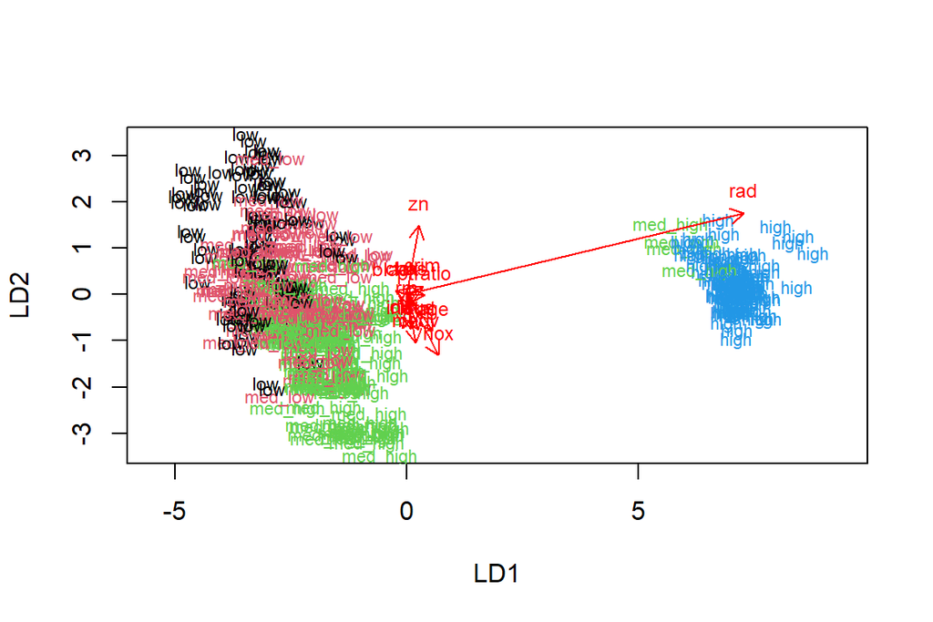

```r
# the function for lda biplot arrows
lda.arrows <- function(x, myscale = 1, arrow_heads = 0.1, color = "red", tex = 0.75, choices = c(1,2)){
  heads <- coef(x)
  graphics::arrows(x0 = 0, y0 = 0,
         x1 = myscale * heads[,choices[1]],
         y1 = myscale * heads[,choices[2]], col=color, length = arrow_heads)
  text(myscale * heads[,choices], labels = row.names(heads),
       cex = tex, col=color, pos=3)
}

# target classes as numeric
classes <- as.numeric(train$crime)

# plot the lda results (select both lines and execute them at the same time!)
plot(lda.fit, dimen = 2,col = classes, pch = classes)
lda.arrows(lda.fit, myscale = 2)
```

# Assignment 5 data analysis

```r
date()
```

```
## [1] "Tue Dec 12 09:31:04 2023"
```

##Analysis

**1. Move the country names to rownames (see Exercise 5.5). Show a graphical overview of the data and show summaries of the variables in the data. Describe and interpret the outputs, commenting on the distributions of the variables and the relationships between them.**

```r
library(tidyverse)
library(ggplot2)
library(GGally)
library(corrplot)
theme_set(theme_bw())
```

```r
human <- read_csv("https://raw.githubusercontent.com/njehh/IODS-project/master/Data/human.csv")
glimpse(human)
```

```
## Rows: 155
## Columns: 9
## $ Country   <chr> "Norway", "Australia", "Switzerland", "Denmark", "Netherland…
## $ Edu2.FM   <dbl> 1.0072389, 0.9968288, 0.9834369, 0.9886128, 0.9690608, 0.992…
## $ Labo.FM   <dbl> 0.8908297, 0.8189415, 0.8251001, 0.8840361, 0.8286119, 0.807…
## $ Edu.Exp   <dbl> 17.5, 20.2, 15.8, 18.7, 17.9, 16.5, 18.6, 16.5, 15.9, 19.2, …
## $ Life.Exp  <dbl> 81.6, 82.4, 83.0, 80.2, 81.6, 80.9, 80.9, 79.1, 82.0, 81.8, …
## $ GNI       <dbl> 64992, 42261, 56431, 44025, 45435, 43919, 39568, 52947, 4215…
## $ Mat.Mor   <dbl> 4, 6, 6, 5, 6, 7, 9, 28, 11, 8, 6, 4, 8, 4, 27, 2, 11, 6, 6,…
## $ Ado.Birth <dbl> 7.8, 12.1, 1.9, 5.1, 6.2, 3.8, 8.2, 31.0, 14.5, 25.3, 6.0, 6…
## $ Parli.F   <dbl> 39.6, 30.5, 28.5, 38.0, 36.9, 36.9, 19.9, 19.4, 28.2, 31.4, …
```

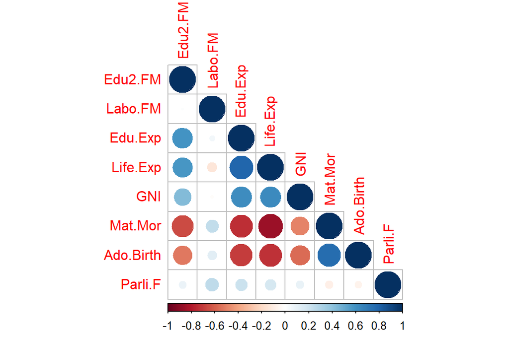

```r
human_ <- column_to_rownames(human, "Country") #Country column to rownames

cor_human <- cor(human_) %>%
  round(digits = 2)

corrplot(cor_human, method="circle", type = "lower")
```

Some of the variables have high correlation with each other. For example life expectancy has negative correlation with maternal mortality (Mat.Mor) and adolescent birthrate (Ado.Birth), which is not surprising. Life expectancy (Life.Exp) correlates with expected years of schooling (Edu.Exp) ratio of secundary education of females to males (Edu2.FM). Gross national income per capita (GNI) has positive correlation with secundary education ration, expected years of schooling, and life expectancy. GNI has negative correlation with maternal mortality and adolescence birth rate.

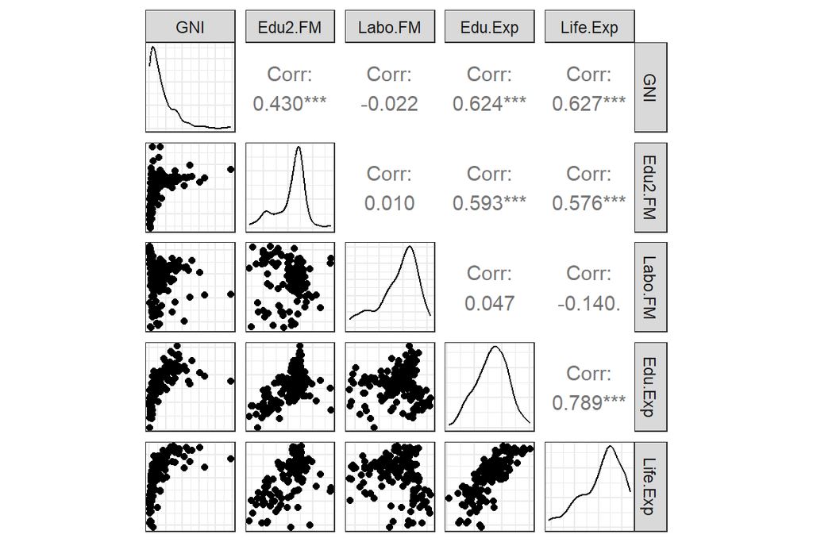

```r
ggpairs(human_, columns = c("GNI", "Edu2.FM", "Labo.FM", "Edu.Exp", "Life.Exp"),
        progress = FALSE, axisLabels = "none") + theme(aspect.ratio = 1)
```

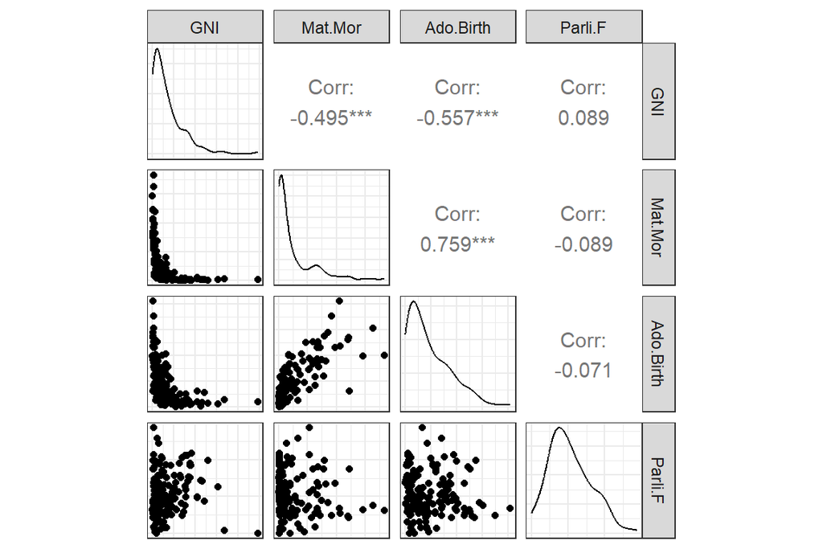

```r
ggpairs(human_, columns = c("GNI", "Mat.Mor", "Ado.Birth","Parli.F"), progress = FALSE, axisLabels = "none") + theme(aspect.ratio = 1)
```

```r
summary(human_)
```

```
##     Edu2.FM          Labo.FM          Edu.Exp         Life.Exp
##  Min.   :0.1717   Min.   :0.1857   Min.   : 5.40   Min.   :49.00
##  1st Qu.:0.7264   1st Qu.:0.5984   1st Qu.:11.25   1st Qu.:66.30
##  Median :0.9375   Median :0.7535   Median :13.50   Median :74.20
##  Mean   :0.8529   Mean   :0.7074   Mean   :13.18   Mean   :71.65
##  3rd Qu.:0.9968   3rd Qu.:0.8535   3rd Qu.:15.20   3rd Qu.:77.25
##  Max.   :1.4967   Max.   :1.0380   Max.   :20.20   Max.   :83.50
##       GNI            Mat.Mor         Ado.Birth         Parli.F
##  Min.   :   581   Min.   :   1.0   Min.   :  0.60   Min.   : 0.00
##  1st Qu.:  4198   1st Qu.:  11.5   1st Qu.: 12.65   1st Qu.:12.40
##  Median : 12040   Median :  49.0   Median : 33.60   Median :19.30
##  Mean   : 17628   Mean   : 149.1   Mean   : 47.16   Mean   :20.91
##  3rd Qu.: 24512   3rd Qu.: 190.0   3rd Qu.: 71.95   3rd Qu.:27.95
##  Max.   :123124   Max.   :1100.0   Max.   :204.80   Max.   :57.50
```

**2. Perform principal component analysis (PCA) on the raw (non-standardized) human data. Show the variability captured by the principal components. Draw a biplot displaying the observations by the first two principal components (PC1 coordinate in x-axis, PC2 coordinate in y-axis), along with arrows representing the original variables.**

```r
pca_human <- prcomp(human_) #principal component analysis

summary(pca_human)
```

```
## Importance of components:
##                              PC1      PC2   PC3   PC4   PC5   PC6    PC7    PC8
## Standard deviation     1.854e+04 185.5219 25.19 11.45 3.766 1.566 0.1912 0.1591
## Proportion of Variance 9.999e-01   0.0001  0.00  0.00 0.000 0.000 0.0000 0.0000
## Cumulative Proportion  9.999e-01   1.0000  1.00  1.00 1.000 1.000 1.0000 1.0000
```

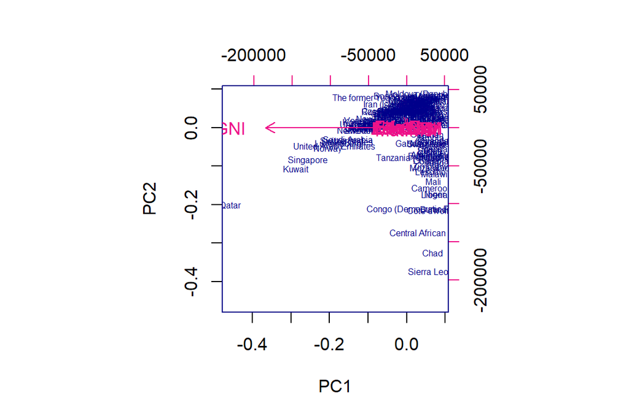

```r
biplot(pca_human, choices = 1:2, cex = c(0.5,1),col = c("darkblue", "deeppink2"))
```

**3. Standardize the variables in the human data and repeat the above analysis. Interpret the results of both analysis (with and without standardizing). Are the results different? Why or why not? Include captions (brief descriptions) in your plots where you describe the results by using not just your variable names, but the actual phenomena they relate to**

```r
human_std <- data.frame(scale(human_))
summary(human_std)
```

```
##     Edu2.FM           Labo.FM           Edu.Exp           Life.Exp
##  Min.   :-2.8189   Min.   :-2.6247   Min.   :-2.7378   Min.   :-2.7188
##  1st Qu.:-0.5233   1st Qu.:-0.5484   1st Qu.:-0.6782   1st Qu.:-0.6425
##  Median : 0.3503   Median : 0.2316   Median : 0.1140   Median : 0.3056
##  Mean   : 0.0000   Mean   : 0.0000   Mean   : 0.0000   Mean   : 0.0000
##  3rd Qu.: 0.5958   3rd Qu.: 0.7350   3rd Qu.: 0.7126   3rd Qu.: 0.6717
##  Max.   : 2.6646   Max.   : 1.6632   Max.   : 2.4730   Max.   : 1.4218
##       GNI             Mat.Mor          Ado.Birth          Parli.F
##  Min.   :-0.9193   Min.   :-0.6992   Min.   :-1.1325   Min.   :-1.8203
##  1st Qu.:-0.7243   1st Qu.:-0.6496   1st Qu.:-0.8394   1st Qu.:-0.7409
##  Median :-0.3013   Median :-0.4726   Median :-0.3298   Median :-0.1403
##  Mean   : 0.0000   Mean   : 0.0000   Mean   : 0.0000   Mean   : 0.0000
##  3rd Qu.: 0.3712   3rd Qu.: 0.1932   3rd Qu.: 0.6030   3rd Qu.: 0.6127
##  Max.   : 5.6890   Max.   : 4.4899   Max.   : 3.8344   Max.   : 3.1850
```

```r
pca_human_std <- prcomp(human_std)
summary(pca_human_std)
```

```
## Importance of components:
##                           PC1    PC2     PC3     PC4     PC5     PC6     PC7
## Standard deviation     2.0708 1.1397 0.87505 0.77886 0.66196 0.53631 0.45900
## Proportion of Variance 0.5361 0.1624 0.09571 0.07583 0.05477 0.03595 0.02634
## Cumulative Proportion  0.5361 0.6984 0.79413 0.86996 0.92473 0.96069 0.98702
##                            PC8
## Standard deviation     0.32224
## Proportion of Variance 0.01298
## Cumulative Proportion  1.00000
```

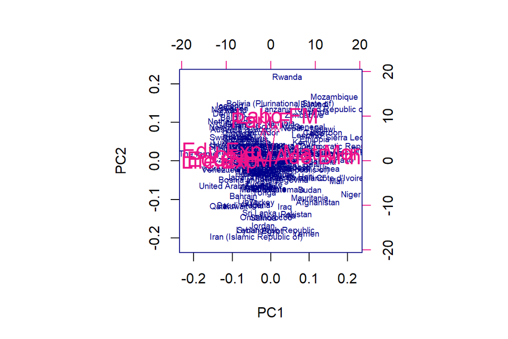

```r
biplot(pca_human_std, choices = 1:2, cex = c(0.6,1.5), arrow.len=0.1, col = c("darkblue", "deeppink2"), xlim = c(-0.22, 0.22), ylim = c(-0.22, 0.22))
```

After the data was centered, as it should be for principal component analysis, it is possible to see the actual effect of different variables. For the first primary component (PC1), maternal mortality (Mat.Mor) and adolescent birth rate (Ado.Birth) increase with the PC1, whereas life expectancy (Life.Exp), expected years of schooling (Edu.Exp), gross national income per capita (GNI), and secundary education ratio of females to men (Edu2.FM) decrease PC1. PC2 increased with the percentage of female representatives in the parliament (Parli.F) and proportion of females in the labour force compared to men (Labo.FM).

**4.interpretation of the PCA with standardised data** It seems that the PC1 is related to variables, which probably associate with birth rate. High maternal mortality and adolescent birth rate probably associate with higher overall birthrate. On the other hand education level of the women and higher GNI probably correlates with lower birthrate. Therefore it could be logical that PCA1 would associate strongly with also the overall birth rate.

PCA2 is defined mainly by the percentage of female representatives in the parliament and proportion of females in the labour force compared to men. It probably tells about the role and possibilities of women in the society. Secundary education ratio of women to men also affects the PCA2, which further supports this interpretation.

**5. Tea.**

```r
tea <- read.csv("https://raw.githubusercontent.com/KimmoVehkalahti/Helsinki-Open-Data-Science/master/datasets/tea.csv", stringsAsFactors = TRUE)
view(tea)
glimpse(tea)
```

```
## Rows: 300
## Columns: 36
## $ breakfast        <fct> breakfast, breakfast, Not.breakfast, Not.breakfast, b…
## $ tea.time         <fct> Not.tea time, Not.tea time, tea time, Not.tea time, N…
## $ evening          <fct> Not.evening, Not.evening, evening, Not.evening, eveni…
## $ lunch            <fct> Not.lunch, Not.lunch, Not.lunch, Not.lunch, Not.lunch…
## $ dinner           <fct> Not.dinner, Not.dinner, dinner, dinner, Not.dinner, d…
## $ always           <fct> Not.always, Not.always, Not.always, Not.always, alway…
## $ home             <fct> home, home, home, home, home, home, home, home, home,…
## $ work             <fct> Not.work, Not.work, work, Not.work, Not.work, Not.wor…
## $ tearoom          <fct> Not.tearoom, Not.tearoom, Not.tearoom, Not.tearoom, N…
## $ friends          <fct> Not.friends, Not.friends, friends, Not.friends, Not.f…
## $ resto            <fct> Not.resto, Not.resto, resto, Not.resto, Not.resto, No…
## $ pub              <fct> Not.pub, Not.pub, Not.pub, Not.pub, Not.pub, Not.pub,…
## $ Tea              <fct> black, black, Earl Grey, Earl Grey, Earl Grey, Earl G…
```

[output cut: 23 more lines]

Dataset has 300 rows and 36 columns.

```r
tea_col <- c("breakfast","evening", "lunch", "dinner", "always")
tea_set <- tea[,tea_col]
```

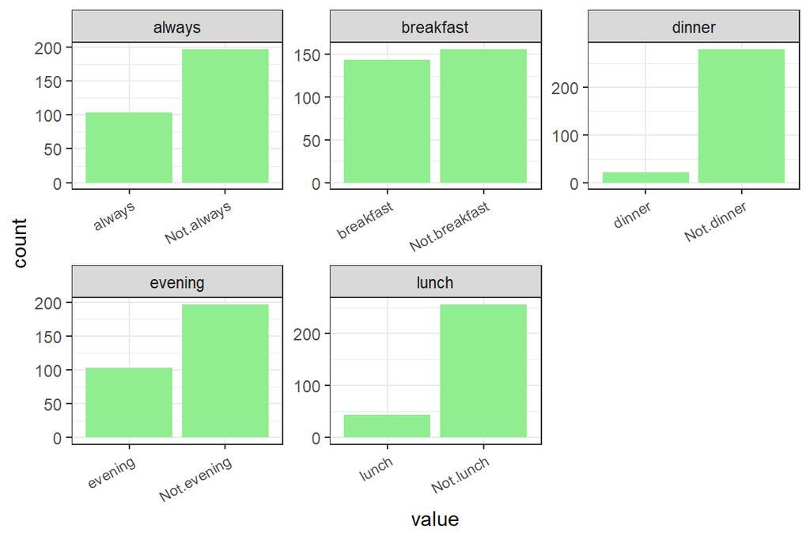

```r
pivot_longer(tea_set, cols = everything()) %>%
  ggplot(aes(value)) + facet_wrap("name", scales = "free")+
  geom_bar(fill="lightgreen")+theme(axis.text.x = element_text(angle = 30, hjust = 1, size = 8))
```

```r
library(FactoMineR)
mca <- MCA(tea_set, graph = FALSE)
```

```r
summary(mca)
```

```
##
## Call:
## MCA(X = tea_set, graph = FALSE)
##
##
## Eigenvalues
##                        Dim.1   Dim.2   Dim.3   Dim.4   Dim.5
## Variance               0.257   0.229   0.209   0.159   0.146
## % of var.             25.651  22.925  20.926  15.931  14.567
## Cumulative % of var.  25.651  48.576  69.502  85.433 100.000
##
## Individuals (the 10 first)
##                  Dim.1    ctr   cos2    Dim.2    ctr   cos2    Dim.3    ctr
## 1             | -0.129  0.021  0.035 | -0.661  0.635  0.919 | -0.018  0.001
## 2             | -0.129  0.021  0.035 | -0.661  0.635  0.919 | -0.018  0.001
## 3             | -1.069  1.486  0.340 |  0.867  1.094  0.224 |  0.915  1.334
## 4             | -1.449  2.727  0.680 |  0.377  0.206  0.046 |  0.561  0.502
## 5             |  0.543  0.384  0.286 |  0.176  0.045  0.030 | -0.322  0.165
## 6             | -1.449  2.727  0.680 |  0.377  0.206  0.046 |  0.561  0.502
## 7             | -0.129  0.021  0.035 | -0.661  0.635  0.919 | -0.018  0.001
## 8             |  0.007  0.000  0.000 |  0.492  0.352  0.335 |  0.311  0.154
## 9             | -0.129  0.021  0.035 | -0.661  0.635  0.919 | -0.018  0.001
## 10            |  0.251  0.082  0.084 | -0.170  0.042  0.038 |  0.336  0.180
##                 cos2
## 1              0.001 |
## 2              0.001 |
## 3              0.249 |
## 4              0.102 |
## 5              0.101 |
## 6              0.102 |
## 7              0.001 |
## 8              0.134 |
## 9              0.001 |
## 10             0.150 |
##
## Categories
##                   Dim.1     ctr    cos2  v.test     Dim.2     ctr    cos2
## breakfast     |   0.321   3.849   0.095   5.328 |  -0.824  28.443   0.627
## Not.breakfast |  -0.296   3.553   0.095  -5.328 |   0.761  26.255   0.627
## evening       |   0.631  10.651   0.208   7.887 |   0.772  17.829   0.311
```

[output cut: 11 more lines]

```
## Not.evening    -9.646 |  -0.278   4.849   0.148  -6.647 |
## lunch           0.298 |   1.236  21.403   0.262   8.858 |
## Not.lunch      -0.298 |  -0.212   3.679   0.262  -8.858 |
## dinner          3.966 |   1.285  11.039   0.124   6.094 |
## Not.dinner     -3.966 |  -0.097   0.831   0.124  -6.094 |
## always          6.811 |  -0.989  32.076   0.511 -12.362 |
## Not.always     -6.811 |   0.517  16.771   0.511  12.362 |
##
## Categorical variables (eta2)
##                 Dim.1 Dim.2 Dim.3
## breakfast     | 0.095 0.627 0.001 |
## evening       | 0.208 0.311 0.148 |
## lunch         | 0.372 0.000 0.262 |
## dinner        | 0.484 0.053 0.124 |
## always        | 0.124 0.155 0.511 |
```

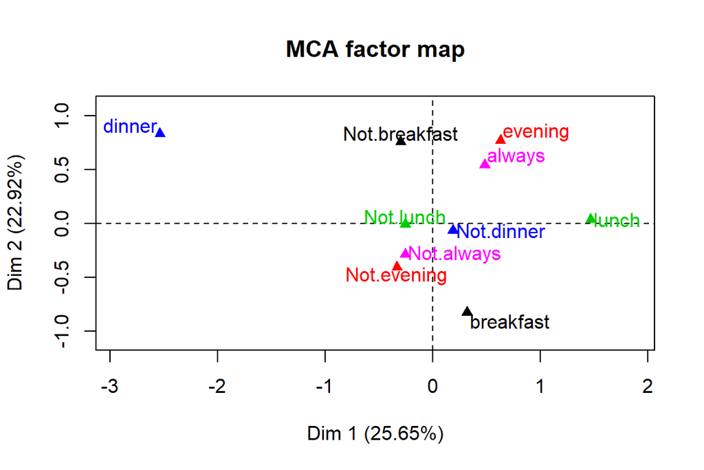

```r
plot(mca, invisible=c("ind"), graph.type = "classic",habillage = "quali")
```

# Assignment 6 data analysis

```r
date()
```

```
## [1] "Tue Dec 12 09:31:09 2023"
```

```r
library(tidyverse)
library(ggplot2)
theme_set(theme_bw())
```

## 1. Rats

```r
rats <- read_csv("https://raw.githubusercontent.com/njehh/IODS-project/master/Data/rats.csv")
rats$ID <- as.factor(rats$ID)
rats$Group <- as.factor(rats$Group)
glimpse(rats)
```

```
## Rows: 176
## Columns: 5
## $ ID     <fct> 1, 2, 3, 4, 5, 6, 7, 8, 9, 10, 11, 12, 13, 14, 15, 16, 1, 2, 3,…
## $ Group  <fct> 1, 1, 1, 1, 1, 1, 1, 1, 2, 2, 2, 2, 3, 3, 3, 3, 1, 1, 1, 1, 1, …
## $ WD     <chr> "WD1", "WD1", "WD1", "WD1", "WD1", "WD1", "WD1", "WD1", "WD1", …
## $ Weight <dbl> 240, 225, 245, 260, 255, 260, 275, 245, 410, 405, 445, 555, 470…
## $ Time   <dbl> 1, 1, 1, 1, 1, 1, 1, 1, 1, 1, 1, 1, 1, 1, 1, 1, 8, 8, 8, 8, 8, …
```

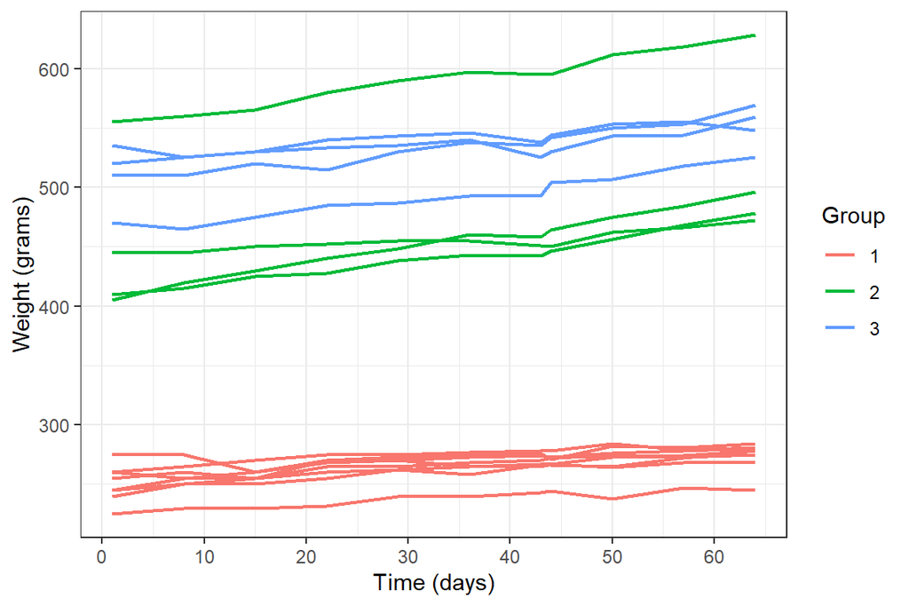

```r
ggplot(rats, aes(x = Time, y = Weight, group = ID, colour = Group)) +
  geom_line(linewidth = 0.8) +
  ylab("Weight (grams)") +
  scale_x_continuous(name = "Time (days)", breaks = seq(0, 60, 10))
```

It seems that there is clear difference in weight between the groups. Also, there is an outlier in group 2.

Lets standardise the data.

```r
rats <- rats %>%
  group_by(Time) %>%
  mutate(stdweight = (Weight - mean(Weight)) / sd(Weight)) %>%
  ungroup()

glimpse(rats)
```

```
## Rows: 176
## Columns: 6
## $ ID        <fct> 1, 2, 3, 4, 5, 6, 7, 8, 9, 10, 11, 12, 13, 14, 15, 16, 1, 2,…
## $ Group     <fct> 1, 1, 1, 1, 1, 1, 1, 1, 2, 2, 2, 2, 3, 3, 3, 3, 1, 1, 1, 1, …
## $ WD        <chr> "WD1", "WD1", "WD1", "WD1", "WD1", "WD1", "WD1", "WD1", "WD1…
## $ Weight    <dbl> 240, 225, 245, 260, 255, 260, 275, 245, 410, 405, 445, 555, …
## $ Time      <dbl> 1, 1, 1, 1, 1, 1, 1, 1, 1, 1, 1, 1, 1, 1, 1, 1, 8, 8, 8, 8, …
## $ stdweight <dbl> -1.0011429, -1.1203857, -0.9613953, -0.8421525, -0.8819001, …
```

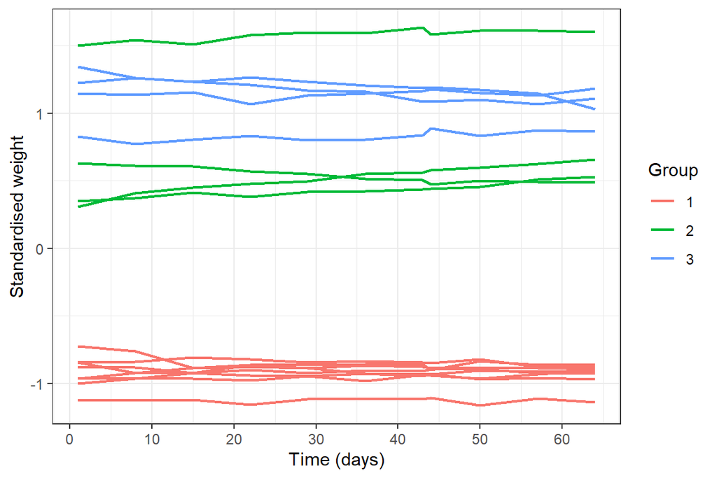

```r
ggplot(rats, aes(x = Time, y = stdweight, group = ID, colour = Group)) +
  geom_line(linewidth = 0.8) +
  ylab("Standardised weight") +
  scale_x_continuous(name = "Time (days)", breaks = seq(0, 60, 10))
```

```r
RATS <- rats %>%
  group_by(ID,Group) %>%
  summarise(mean=mean(Weight)) %>%
  ungroup()
```

[output not shown]

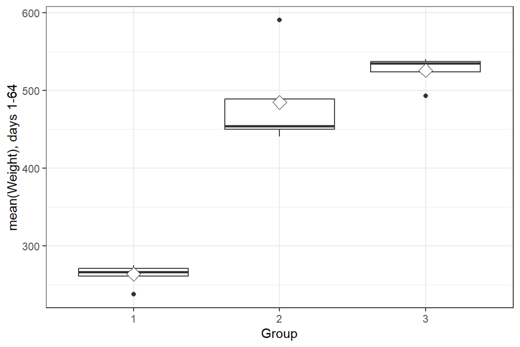

```r
ggplot(RATS, aes(x = Group, y = mean)) +
  geom_boxplot() +
  stat_summary(fun = "mean", geom = "point", shape=23, size=4, fill = "white") +
  scale_y_continuous(name = "mean(Weight), days 1-64")
```

```r
lm.rat <- lm(mean ~Group, data = RATS)
summary(lm.rat)
```

```
##
## Call:
## lm(formula = mean ~ Group, data = RATS)
##
## Residuals:
##     Min      1Q  Median      3Q     Max
## -43.886 -27.031   2.284  10.588 105.750
##
## Coefficients:
##             Estimate Std. Error t value Pr(>|t|)
## (Intercept)   263.72      12.96  20.346 3.06e-11 ***
## Group2        220.99      22.45   9.844 2.16e-07 ***
## Group3        262.08      22.45  11.674 2.91e-08 ***
## ---
## Signif. codes:  0 '***' 0.001 '**' 0.01 '*' 0.05 '.' 0.1 ' ' 1
##
## Residual standard error: 36.66 on 13 degrees of freedom
## Multiple R-squared:  0.9313, Adjusted R-squared:  0.9207
## F-statistic: 88.07 on 2 and 13 DF,  p-value: 2.763e-08
```

```r
anova(lm.rat)
```

```
## Analysis of Variance Table
##
## Response: mean
##           Df Sum Sq Mean Sq F value    Pr(>F)
## Group      2 236732  118366  88.073 2.763e-08 ***
## Residuals 13  17471    1344
## ---
## Signif. codes:  0 '***' 0.001 '**' 0.01 '*' 0.05 '.' 0.1 ' ' 1
```

## 2. BPRS

```r
BPRS <- read_csv("https://raw.githubusercontent.com/njehh/IODS-project/master/Data/bprs.csv")
BPRS$treatment <- as.factor(BPRS$treatment)
BPRS$subject <- as.factor(BPRS$subject)
glimpse(BPRS)
```

```
## Rows: 360
## Columns: 5
## $ treatment <fct> 1, 1, 1, 1, 1, 1, 1, 1, 1, 1, 1, 1, 1, 1, 1, 1, 1, 1, 1, 1, …
## $ subject   <fct> 1, 2, 3, 4, 5, 6, 7, 8, 9, 10, 11, 12, 13, 14, 15, 16, 17, 1…
## $ weeks     <chr> "week0", "week0", "week0", "week0", "week0", "week0", "week0…
## $ bprs      <dbl> 42, 58, 54, 55, 72, 48, 71, 30, 41, 57, 30, 55, 36, 38, 66, …
## $ week      <dbl> 0, 0, 0, 0, 0, 0, 0, 0, 0, 0, 0, 0, 0, 0, 0, 0, 0, 0, 0, 0, …
```

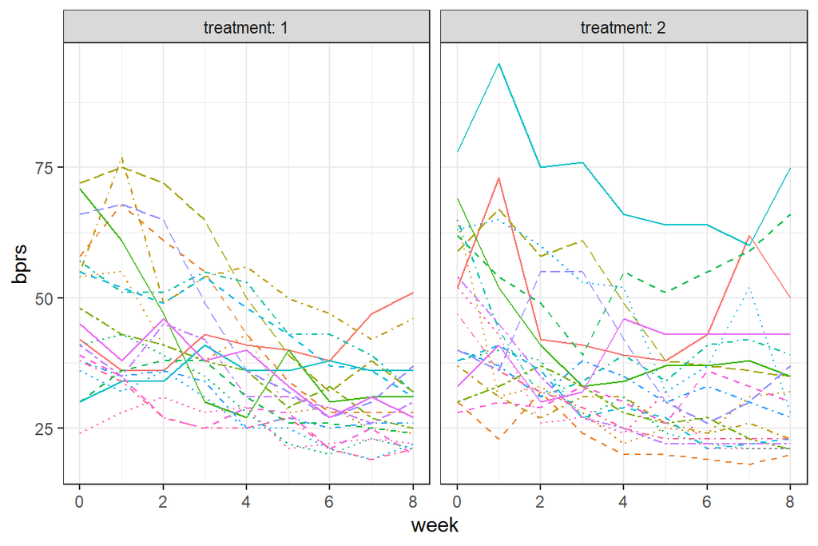

```r
ggplot(BPRS, aes(x = week, y = bprs, linetype =subject, colour=subject)) +
  geom_line() +
  scale_linetype_manual(values = rep(1:10, times=4)) +
  theme(legend.position = "none") +
  facet_grid(. ~ treatment, labeller = label_both)
```